# Exercise: Inference of admixture and population structure

Individuals are not always descended from a single population. If populations that have been separated for a long time meet again, the offspring carry a genome that is a mosaic of both, and a few generations later a chromosome is a patchwork of stretches from either source. The *admixture model* ignores where along the genome those stretches are and asks a simpler question: **what fraction of this individual's genome comes from each of K ancestral populations?**

The model has two sets of unknowns, and both are estimated from the data at the same time:

- **f** - the allele frequency of every site in each of the K ancestral populations (the `fopt` file)
- **Q** - the admixture proportions of every individual, K numbers per individual that sum to 1 (the `qopt` file)

Given `f` and `Q`, the expected allele frequency for one individual at one site is just its own mixture of the ancestral frequencies, and the genotype is assumed to be drawn from Hardy-Weinberg with that frequency. The programs then look for the `f` and `Q` that make the observed data most likely.

Two things follow from this that we will spend most of the exercise on:

- there is no closed form solution, so the estimate is found by numerical optimisation from a random starting point, and it can get stuck in a **local optimum**
- the model can be fitted to any data whatsoever, which does not mean the data fit the model - we need a separate tool, **evalAdmix**, to ask whether the result should be believed at all

### What we will do

|  | Tool | Data | Question |
| --- | --- | --- | --- |
| **A** | NGSadmix + evalAdmix | many low depth samples from 5 human populations | estimate admixture proportions from genotype likelihoods, check convergence and model fit |
| **B** | fastNGSadmix | 3 single samples | infer the ancestry of one sample against a reference panel |
| **C** | ADMIXTURE + evalAdmix | called genotypes | the same questions for high depth/genotype data (separate notebook) |

## Setup

The first cell only defines paths. So that nothing breaks if you restart the kernel or run cells out of order, it writes the paths to a small file (`env.sh`) and every later bash cell starts by reading that file back in with `source`. The file also does `cd` into your working folder, so all later commands can use short relative paths.

The data folder is linked into the working folder as `data`, which means the R cells can reach it as `~/advBinf/admixtureHuman/data/...` without knowing about any shell variable.

```
# ---------------------------------------------------------------------------
# where the course data is (only change this if the course files have moved)
# ---------------------------------------------------------------------------
DATA_PATH=/course/advBinf/admixtureHuman

# our own working folder
WORK=~/advBinf/admixtureHuman
mkdir -p $WORK

# ---------------------------------------------------------------------------
# write the paths to a file so that every later cell can get them back with
# a single "source ~/advBinf/admixtureHuman/env.sh"
# ---------------------------------------------------------------------------
cat > $WORK/env.sh <<EOF
export DATA_PATH=$DATA_PATH
export BAMFOLDER=$DATA_PATH/smallbams
export ANGSD=angsd
export NGSadmix=NGSadmix
export EVALADMIX=evalAdmix
export fastNGSadmix=fastNGSadmix
cd $WORK
EOF

source $WORK/env.sh

# make the data visible from the working folder (symbolic link, no copying)
ln -sfn $DATA_PATH data

# the small json files with the quiz questions
cp -sf $DATA_PATH/quiz/*.json .

echo "--- programs that are installed ---"
type angsd NGSadmix evalAdmix fastNGSadmix

echo -e "\n--- the working folder ---"
pwd
ls
```

There are a few quizzes along the way. They are run from Python, so we also need to point the Python kernel at the working folder.

```
# set up the python working space
import os

work_d = os.path.expanduser("~/advBinf/admixtureHuman")
os.chdir(work_d)
print(work_d)
```

```
/home/albrecht/advBinf/admixtureHuman
```

## First small example

We will first try to run an NGSadmix analysis of a small dataset consisting of bam files with low depth NGS data from 435 samples of 5 human populations from the 1000 genomes project:

| Population code | Population | Sample size |
| --- | --- | --- |
| ASW | HapMap African ancestry individuals from SW US | 61 |
| CEU | European individuals | 99 |
| CHB | Han Chinese in Beijing | 103 |
| YRI | Yoruba individuals from Nigeria | 108 |
| MXL | Mexican individuals from LA California | 64 |

### Make input data using ANGSD

The input to NGSadmix is genotype likelihoods (GLs). Therefore the first step of running an NGSadmix analysis (if all you have are bams files) is to calculate GLs. So let's start bying doing that. First make a file that contains the paths of all the bam files by finding all the names of the bamfiles in the relevant folder and saving this in a file called all.files:

### Why genotype likelihoods and not genotypes

These samples are sequenced to a few reads per site. At that depth a large fraction of the sites in an individual are covered by a single read, and a single read can never distinguish a heterozygote from a homozygote - so calling the genotype would systematically turn heterozygotes into homozygotes. Instead of calling, ANGSD computes for every site and every individual the likelihood of each of the three possible genotypes given the reads and their base qualities. A site with one read gives a flat, uninformative likelihood; a site with ten reads gives a sharp one. NGSadmix then works directly on these likelihoods, so the uncertainty is part of the model rather than a source of bias.

```
source ~/advBinf/admixtureHuman/env.sh   # paths + cd to the working folder

find $BAMFOLDER | grep bam$ > all.files
```

To see the content of the file you made type:

```
source ~/advBinf/admixtureHuman/env.sh   # paths + cd to the working folder

cat all.files
```

```
/course/advBinf/admixtureHuman/smallbams/small.NA19731.mapped.ILLUMINA.bwa.MXL.low_coverage.20120522.bam
/course/advBinf/admixtureHuman/smallbams/small.NA07037.mapped.ILLUMINA.bwa.CEU.low_coverage.20130502.bam
/course/advBinf/admixtureHuman/smallbams/small.NA18611.mapped.ILLUMINA.bwa.CHB.low_coverage.20120522.bam
/course/advBinf/admixtureHuman/smallbams/small.NA19679.mapped.ILLUMINA.bwa.MXL.low_coverage.20120522.bam
/course/advBinf/admixtureHuman/smallbams/small.NA18868.mapped.ILLUMINA.bwa.YRI.low_coverage.20120522.bam
/course/advBinf/admixtureHuman/smallbams/small.NA19121.mapped.ILLUMINA.bwa.YRI.low_coverage.20130415.bam
/course/advBinf/admixtureHuman/smallbams/small.NA19116.mapped.ILLUMINA.bwa.YRI.low_coverage.20120522.bam
/course/advBinf/admixtureHuman/smallbams/small.NA18632.mapped.ILLUMINA.bwa.CHB.low_coverage.20130415.bam
/course/advBinf/admixtureHuman/smallbams/small.NA18504.mapped.ILLUMINA.bwa.YRI.low_coverage.20120522.bam
/course/advBinf/admixtureHuman/smallbams/small.NA18645.mapped.ILLUMINA.bwa.CHB.low_coverage.20130415.bam
/course/advBinf/admixtureHuman/smallbams/small.NA12890.mapped.ILLUMINA.bwa.CEU.low_coverage.20130415.bam
/course/advBinf/admixtureHuman/smallbams/small.NA20318.mapped.ILLUMINA.bwa.ASW.low_coverage.20130415.bam
/course/advBinf/admixtureHuman/smallbams/small.NA19682.mapped.ILLUMINA.bwa.MXL.low_coverage.20120522.bam
/course/advBinf/admixtureHuman/smallbams/small.NA18908.mapped.ILLUMINA.bwa.YRI.low_coverage.20120522.bam
/course/advBinf/admixtureHuman/smallbams/small.NA12830.mapped.ILLUMINA.bwa.CEU.low_coverage.20130415.bam
/course/advBinf/admixtureHuman/smallbams/small.NA18559.mapped.ILLUMINA.bwa.CHB.low_coverage.20130415.bam
/course/advBinf/admixtureHuman/smallbams/small.NA19649.mapped.ILLUMINA.bwa.MXL.low_coverage.20120522.bam
/course/advBinf/admixtureHuman/smallbams/small.NA18870.mapped.ILLUMINA.bwa.YRI.low_coverage.20130415.bam
/course/advBinf/admixtureHuman/smallbams/small.NA19197.mapped.ILLUMINA.bwa.YRI.low_coverage.20120522.bam
/course/advBinf/admixtureHuman/smallbams/small.NA18555.mapped.ILLUMINA.bwa.CHB.low_coverage.20130415.bam
/course/advBinf/admixtureHuman/smallbams/small.NA18570.mapped.ILLUMINA.bwa.CHB.low_coverage.20130415.bam
/course/advBinf/admixtureHuman/smallbams/small.NA20282.mapped.ILLUMINA.bwa.ASW.low_coverage.20120522.bam
/course/advBinf/admixtureHuman/smallbams/small.NA20356.mapped.ILLUMINA.bwa.ASW.low_coverage.20120522.bam
/course/advBinf/admixtureHuman/smallbams/small.NA18552.mapped.ILLUMINA.bwa.CHB.low_coverage.20130415.bam
/course/advBinf/admixtureHuman/smallbams/small.NA18539.mapped.ILLUMINA.bwa.CHB.low_coverage.20120522.bam
/course/advBinf/admixtureHuman/smallbams/small.NA18534.mapped.ILLUMINA.bwa.CHB.low_coverage.20120522.bam
/course/advBinf/admixtureHuman/smallbams/small.NA12718.mapped.ILLUMINA.bwa.CEU.low_coverage.20120522.bam
/course/advBinf/admixtureHuman/smallbams/small.NA20314.mapped.ILLUMINA.bwa.ASW.low_coverage.20120522.bam
/course/advBinf/admixtureHuman/smallbams/small.NA19749.mapped.ILLUMINA.bwa.MXL.low_coverage.20120522.bam
/course/advBinf/admixtureHuman/smallbams/small.NA19720.mapped.ILLUMINA.bwa.MXL.low_coverage.20120522.bam
/course/advBinf/admixtureHuman/smallbams/small.NA18878.mapped.ILLUMINA.bwa.YRI.low_coverage.20130415.bam
/course/advBinf/admixtureHuman/smallbams/small.NA19716.mapped.ILLUMINA.bwa.MXL.low_coverage.20120522.bam
/course/advBinf/admixtureHuman/smallbams/small.NA19152.mapped.ILLUMINA.bwa.YRI.low_coverage.20120522.bam
/course/advBinf/admixtureHuman/smallbams/small.NA19138.mapped.ILLUMINA.bwa.YRI.low_coverage.20130415.bam
/course/advBinf/admixtureHuman/smallbams/small.NA19107.mapped.ILLUMINA.bwa.YRI.low_coverage.20130415.bam
/course/advBinf/admixtureHuman/smallbams/small.NA11933.mapped.ILLUMINA.bwa.CEU.low_coverage.20130415.bam
/course/advBinf/admixtureHuman/smallbams/small.NA19108.mapped.ILLUMINA.bwa.YRI.low_coverage.20130415.bam
/course/advBinf/admixtureHuman/smallbams/small.NA20296.mapped.ILLUMINA.bwa.ASW.low_coverage.20120522.bam
/course/advBinf/admixtureHuman/smallbams/small.NA18642.mapped.ILLUMINA.bwa.CHB.low_coverage.20130415.bam
/course/advBinf/admixtureHuman/smallbams/small.NA18577.mapped.ILLUMINA.bwa.CHB.low_coverage.20130415.bam
```

[output cut: 380 more lines]

```
/course/advBinf/admixtureHuman/smallbams/small.NA19789.mapped.ILLUMINA.bwa.MXL.low_coverage.20120522.bam
/course/advBinf/admixtureHuman/smallbams/small.NA18915.mapped.ILLUMINA.bwa.YRI.low_coverage.20130502.bam
/course/advBinf/admixtureHuman/smallbams/small.NA12006.mapped.ILLUMINA.bwa.CEU.low_coverage.20121211.bam
/course/advBinf/admixtureHuman/smallbams/small.NA18874.mapped.ILLUMINA.bwa.YRI.low_coverage.20120522.bam
/course/advBinf/admixtureHuman/smallbams/small.NA19117.mapped.ILLUMINA.bwa.YRI.low_coverage.20130415.bam
/course/advBinf/admixtureHuman/smallbams/small.NA20281.mapped.ILLUMINA.bwa.ASW.low_coverage.20120522.bam
/course/advBinf/admixtureHuman/smallbams/small.NA19773.mapped.ILLUMINA.bwa.MXL.low_coverage.20120522.bam
/course/advBinf/admixtureHuman/smallbams/small.NA12776.mapped.ILLUMINA.bwa.CEU.low_coverage.20130415.bam
/course/advBinf/admixtureHuman/smallbams/small.NA19657.mapped.ILLUMINA.bwa.MXL.low_coverage.20120522.bam
/course/advBinf/admixtureHuman/smallbams/small.NA18599.mapped.ILLUMINA.bwa.CHB.low_coverage.20130415.bam
/course/advBinf/admixtureHuman/smallbams/small.NA18605.mapped.ILLUMINA.bwa.CHB.low_coverage.20130415.bam
/course/advBinf/admixtureHuman/smallbams/small.NA19901.mapped.ILLUMINA.bwa.ASW.low_coverage.20120522.bam
/course/advBinf/admixtureHuman/smallbams/small.NA10847.mapped.ILLUMINA.bwa.CEU.low_coverage.20130502.bam
/course/advBinf/admixtureHuman/smallbams/small.NA20321.mapped.ILLUMINA.bwa.ASW.low_coverage.20130415.bam
/course/advBinf/admixtureHuman/smallbams/small.NA19819.mapped.ILLUMINA.bwa.ASW.low_coverage.20120522.bam
```

As you can see it is a list of paths to bams files (a line per bam file). Each bam file contains data from a single individual and the population a given individual is from is indicated as a part of the bam file name (if we divide the path/file name into text bites between "." it is the 6th text bite). To see how many individuals there is data for from each population we can therefore count how many bam file names there are with each of the different populations as part of their name:

```
source ~/advBinf/admixtureHuman/env.sh   # paths + cd to the working folder

cat all.files | cut -d'.' -f6 | sort | uniq -c
```

```
     61 ASW
     99 CEU
    103 CHB
     64 MXL
    108 YRI
```

- Does this fit the info you were given above about the dataset? (Which populations, number of individuals from each of the populations, total number of individuals)

Now calculate GLs from all the BAM files using ANGSD by running the following command in the terminal:

Here is what the options mean:

```
-bam all.files   : the bam files to calculate genotype likelihoods from are listed in all.files
-GL 2            : use the GATK genotype likelihood model
-doMajorMinor 1  : infer the major and minor allele from the data
-doMaf 1         : estimate the minor allele frequency (needed by -SNP_pval and -minMaf below)
-SNP_pval 2e-6   : only keep sites that are variable with a p-value below 2e-6
-minMapQ 30      : discard reads with a mapping quality below 30
-minQ 20         : discard bases with a base quality below 20
-minInd 25       : only keep sites with data for at least 25 individuals
-minMaf 0.05     : only keep sites with a minor allele frequency above 0.05
-doGlf 2         : write the genotype likelihoods in beagle format
-out all         : name all output files "all" followed by the appropriate suffix
-P 5             : use 5 threads
```

Note that we are calling SNPs and filtering on allele frequency *across all 435 samples at once*. That is deliberate: the sites we keep should not depend on which population an individual came from.

```
source ~/advBinf/admixtureHuman/env.sh   # paths + cd to the working folder

$ANGSD -bam all.files -GL 2 -doMajorMinor 1 -doMaf 1 -SNP_pval 2e-6 -minMapQ 30 -minQ 20 -minInd 25 -minMaf 0.05 -doGlf 2 -out all -P 5
```

```
	-> angsd version: 0.941-21-g8a58e17 (htslib: 1.18-17-g5acbc15) build(Sep 10 2023 10:54:12)
	-> angsd -bam all.files -GL 2 -doMajorMinor 1 -doMaf 1 -SNP_pval 2e-6 -minMapQ 30 -minQ 20 -minInd 25 -minMaf 0.05 -doGlf 2 -out all -P 5
	-> Inputtype is BAM/CRAM
[multiReader] 435 samples in 435 input files
	-> SNP-filter using a pvalue: 2.000000e-06 correspond to 22.595043 likelihood units
	-> Parsing 435 number of samples

	-> Allocated ~ 10 million nodes to the nodepool, this is not an estimate of the memory usage

	-> Allocated ~ 20 million nodes to the nodepool, this is not an estimate of the memory usage

	-> Allocated ~ 30 million nodes to the nodepool, this is not an estimate of the memory usage

	-> Allocated ~ 40 million nodes to the nodepool, this is not an estimate of the memory usage

	-> Allocated ~ 50 million nodes to the nodepool, this is not an estimate of the memory usage

	-> Allocated ~ 60 million nodes to the nodepool, this is not an estimate of the memory usage

	-> Allocated ~ 70 million nodes to the nodepool, this is not an estimate of the memory usage

	-> Allocated ~ 80 million nodes to the nodepool, this is not an estimate of the memory usage

	-> Allocated ~ 90 million nodes to the nodepool, this is not an estimate of the memory usage

	-> Allocated ~ 100 million nodes to the nodepool, this is not an estimate of the memory usage
	-> Printing at chr: 14 pos:20692360 chunknumber 200 contains 699 sites
	-> Done reading data waiting for calculations to finish
	-> Done waiting for threads
	-> Output filenames:
		->"all.arg"
		->"all.beagle.gz"
		->"all.mafs.gz"
	-> Mon Sep 14 12:51:34 2026
	-> Arguments and parameters for all analysis are located in .arg file
	-> Total number of sites analyzed: 167518
	-> Number of sites retained after filtering: 1306
	[ALL done] cpu-time used =  97.99 sec
	[ALL done] walltime used =  51.00 sec
```

NOTE that this will take a bit of time to run (around a minute). While waiting, try to remember what the different options used mean (you have seen most of them in previous exercises). If you do not remember all of them, then try to ask the person next to you. And if neither of you remember then try to figure it out by looking for help on the ANGSD webpage e.g. [here](http://www.popgen.dk/angsd/index.php/Genotype_Likelihoods), [here](http://www.popgen.dk/angsd/index.php/Major_Minor) and [here](http://www.popgen.dk/angsd/index.php/Filters).

## Explore the input data

Now let's have a look at the GL file that you have created with ANGSD. It is a "beagle format" file called all.beagle.gz - and will be the input file to NGSadmix. The first line in this file is a header line and after that it contains a line for each locus with GLs. By using the unix command wc we can count the number of lines in the file:

```
source ~/advBinf/admixtureHuman/env.sh   # paths + cd to the working folder

gunzip -c all.beagle.gz | wc -l
```

```
1307
```

- Use this to find out how many loci there are GLs for in the data set?

Next, to get an idea of what the GL file contains try from the command line to print the first 9 columns of the first 7 lines of the file:

```
source ~/advBinf/admixtureHuman/env.sh   # paths + cd to the working folder

zcat all.beagle.gz | awk '(NR<=7)' | cut -f1-9 | column -t
```

```
marker      allele1  allele2  Ind0      Ind0      Ind0      Ind1      Ind1      Ind1
1_20018051  2        1        0.000559  0.333333  0.666108  0.941172  0.058828  0.000000
1_20018077  1        3        0.000267  0.999733  0.000000  0.969690  0.030310  0.000000
1_20018091  3        1        0.000846  0.999154  0.000000  0.984609  0.015391  0.000000
1_20018096  2        0        0.000000  0.998312  0.001688  0.032626  0.967374  0.000000
1_20018195  2        0        0.941169  0.058831  0.000000  0.969683  0.030317  0.000000
1_20050859  3        1        0.000000  0.111128  0.888872  0.999023  0.000977  0.000000
```

In general, the first three columns of a beagle file contain the locus name, and the two alleles, allele1 and allele2, present in that locus (in beagle A=0, C=1, G=2, T=3). All following columns contain genotype likelihoods (three columns for each individual: first GL for homozygote for allele1, then GL for heterozygote and then GL for homozygote for allele2). Note that the GL values sum to one per site for each individuals. This is just a normalization of the genotype likelihoods in order to avoid underflow problems in the beagle software it does not mean that they are genotype probabilities.

Based on this:

- What is the name of the first locus?
- Which nucleotide is allele2 in the first locus?
- What is the most likely genotype for ind0 in the first locus?

### Quiz

```
from jupyterquiz import display_quiz
display_quiz('admix_quiz1.json')
```

## Run an analysis of the data with NGSadmix

Now you know how the input looks. Next, let's try to perform an NGSadmix analyses of the GLs typing assuming the number of ancestral populations, K, is 3:

The options are:

```
-likes all.beagle.gz : the genotype likelihoods to analyse
-K 3                 : assume 3 ancestral populations
-minMaf 0.05         : ignore sites where the estimated minor allele frequency is below 0.05
-seed 1              : the seed for the random starting point of the optimisation
-o all               : prefix for the output files
```

Sites with a very low minor allele frequency carry almost no information about ancestry but still cost time, which is why they are filtered out. The `-seed` is the one to keep an eye on - it decides where the optimisation starts, and we will come back to it.

```
source ~/advBinf/admixtureHuman/env.sh   # paths + cd to the working folder

$NGSadmix -likes all.beagle.gz -K 3 -minMaf 0.05 -seed 1 -o all
```

```
Input: lname=all.beagle.gz nPop=3, fname=(null) qname=(null) outfiles=all
Setup: seed=1 nThreads=1 method=1
Convergence: maxIter=2000 tol=0.000010 tolLike50=0.100000 dymBound=0
Filters: misTol=0.050000 minMaf=0.050000 minLrt=0.000000 minInd=0
Input file has dim: nsites=1306 nind=435
Input file has dim (AFTER filtering): nsites=1306 nind=435
iter[start] like is=725007.646639
iter[50] like is=-454726.015786 thres=0.010253
iter[100] like is=-454476.133576 thres=0.007410
EM accelerated has reached convergence with tol 0.000010
best like=-454474.778286 after 145 iterations
	-> Dumpedfiles are: all.log
	-> Dumpedfiles are: all.qopt
	-> Dumpedfiles are: all.fopt.gz
	[ALL done] cpu-time used =  5.25 sec
	[ALL done] walltime used =  5.00 sec
```

- When it is done you will see some output above. While waiting for the analysis to finish running please make sure you understand the command you ran. If you are in doubt seek help [here](http://www.popgen.dk/software/index.php/NgsAdmix#Parameters). Here you can also see what other options you have when you run an NGSadmix analyses.

## Explore the output

The output from the analysis you just ran is three files:

- all.log (a "log file" that summarizes the analysis run)
- all.fopt.gz (an "fopt file", which has a line for each locus that contains an estimate of the allele frequency in each of the 3 assumed ancestral populations)
- all.qopt (a "qopt file", which has a line for each individual that contains anestimate of the individual's ancestry proportion from each of the three assumed ancestral populations).

Let's have a look at them one at a time. First, check the log file by typing

```
source ~/advBinf/admixtureHuman/env.sh   # paths + cd to the working folder

cat all.log
```

```
Input: lname=all.beagle.gz nPop=3, fname=(null) qname=(null) outfiles=all
Setup: seed=1 nThreads=1 method=1
Convergence: maxIter=2000 tol=0.000010 tolLike50=0.100000 dymBound=0
Filters: misTol=0.050000 minMaf=0.050000 minLrt=0.000000 minInd=0
Input file has dim: nsites=1306 nind=435
Input file has dim (AFTER filtering): nsites=1306 nind=435
	[ALL done] cpu-time used =  5.25 sec
	[ALL done] walltime used =  5.00 sec
best like=-454474.778286 after 145 iterations
```

- What is the log likelihood of the estimates achieved by NGSadmix (called "best like" in the log file)?

Next, check the first line of the fopt file by typing:

```
source ~/advBinf/admixtureHuman/env.sh   # paths + cd to the working folder

zcat all.fopt.gz | awk 'NR==1'
```

```
0.29904640512855990009 0.38077570967368778998 0.74494733277312485953
```

- Based on this: what is the estimated allele frequency at the first locus in the three assumed ancestral populations?

Finally, check the 6th line of the qopt file and thus the estimated admixture proportions for the 6th individual by typing:

```
source ~/advBinf/admixtureHuman/env.sh   # paths + cd to the working folder

head -n6 all.qopt | tail -n1
```

```
0.00000000099999999997 0.99999999799999994554 0.00000000099999999997
```

- Based on this: does the individual look admixed?

You can see the ID of the 6th individual by getting the 6th line of the file you created with all your original bam files in the beginning:

```
source ~/advBinf/admixtureHuman/env.sh   # paths + cd to the working folder

head -n6 all.files | tail -n1
```

```
/course/advBinf/admixtureHuman/smallbams/small.NA19121.mapped.ILLUMINA.bwa.YRI.low_coverage.20130415.bam
```

- Based on that ID, which population does the individual come from?
- Based on this and the frequency estimates for the first locus that you looked at earlier, what does NGSadmix estimate the allele frequency to be at the first locus in that population?

## Plot the admixture proportion estimates

Finally, let us plot the estimated admixture proportions for all the individuals. The next cell runs in R.

```
# Get ID and pop info for each individual
s<-strsplit(basename(scan("~/advBinf/admixtureHuman/all.files",what="theFuck")),"\\.")
pop<-sapply(s,function(x) x[6])

# Import some functions to help in visualization
source("https://raw.githubusercontent.com/GenisGE/evalAdmix/master/visFuns.R")

# Read in inferred admixture proportions
q<-read.table("~/advBinf/admixtureHuman/all.qopt")

# Order individuals by population, and within population by admixture proportion
ord <- orderInds(pop=pop,q=q, popord=c("YRI", "ASW", "CEU", "MXL", "CHB"))

# Make plot
par(mar=c(7,4,1,1))
barplot(t(q)[,ord],col=c(3,2,4),las=2,xlab="Individuals",ylab="Admixture proportions", space=0, border=NA)
text(sort(tapply(1:length(pop),pop[ord],mean)),-0.05,unique(pop[ord]),xpd=NA)
abline(v=cumsum(sapply(unique(pop[ord]),function(x){sum(pop[ord]==x)})),col=1,lwd=1.2)
```

```
Read 435 items
```

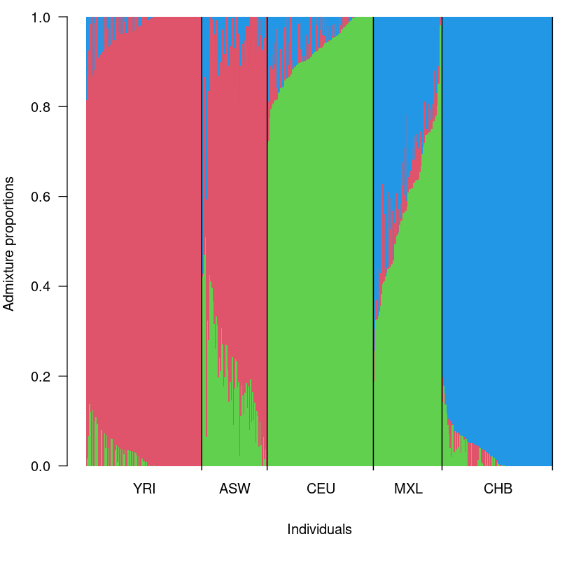

Note that the order of the individuals in the plot are not the same as in the qopt file. Instead, to provide a better overview, the individuals have been ordered according to the population they are sampled from.

- Try to explain what the plot shows (what is on the axes, what do the colors mean and so on)
- What does the plot suggest about whether the individuals are admixed?

NB As you could tell from the number of loci included in the analysis, the above analysis is based on data from very few loci (actually we on purpose only analyzed data from a small part of the genome to make sure the analysis ran fast). In the following we will redo the analyses using a larger number of sites.

### Quiz

```
from jupyterquiz import display_quiz
display_quiz('admix_quiz2.json')
```

## More realistic example

Now you know how to make input data to NGSadmix, how to run NGSadmix and what the output looks like. We will try now to run a more realistic dataset, using the same samples with a larger number of sites. We have already made the input file with genotype likelihoods for 100 000 sites across the genome, and a file with population info.

- the genotype likelihoods of all 435 individuals in beagle format: `data/admixinput/1000G5pops.inputgl.beagle.gz`
- a file with labels that indicate which population each of them is sampled from: `data/admixinput/1000G5pops.pop.info`

## Run an analysis of the data with NGSadmix

We start by running an NGSadmix analyses with K=3 (-K 3), using 10 cpu threads (-P 10) and using only SNPs with minor allele frequency above 0.05 (-minMaf 0.05). Furthermore, to make sure we reach the maximum likelihood solution and not a local optima, we should run 20 independent optimizations runs (-seed i for i in 1:20).

(NB. Because running this would be too computationally intense to run everyone at the same time on the server, we have already run it and the following code just prints the commands you would need to run).

### Why one run is not enough

NGSadmix maximises the likelihood by starting from a random guess for `f` and `Q` and improving it step by step. Each step increases the likelihood, so the algorithm always ends somewhere it cannot improve on locally - but that place need not be the best solution overall. Where it ends depends on where it started, and where it starts is decided by the seed.

The only practical defence is to run the same analysis from many different starting points and compare the likelihoods they reach. If most runs reach the same, highest value, we have reasonable confidence that this is the global maximum. If every run ends somewhere different, the estimate should not be trusted - and note that you cannot average the runs, because the K clusters come out in an arbitrary order and the first column of one run is not the same ancestral population as the first column of another.

```
source ~/advBinf/admixtureHuman/env.sh   # paths + cd to the working folder

inputpath=~/advBinf/admixtureHuman/data/admixinput/1000G5pops.inputgl.beagle.gz
outpath=~/advBinf/admixtureHuman/data/admixoutput
K=3

for i in `seq 1 20`
do
    echo "$NGSadmix -likes $inputpath -K $K -P 10 -minMaf 0.05 -seed $i -o ${outpath}/1000G5popsAdmixK${K}seed${i}"
done
```

```
NGSadmix -likes /home/albrecht/advBinf/admixtureHuman/data/admixinput/1000G5pops.inputgl.beagle.gz -K 3 -P 10 -minMaf 0.05 -seed 1 -o /home/albrecht/advBinf/admixtureHuman/data/admixoutput/1000G5popsAdmixK3seed1
NGSadmix -likes /home/albrecht/advBinf/admixtureHuman/data/admixinput/1000G5pops.inputgl.beagle.gz -K 3 -P 10 -minMaf 0.05 -seed 2 -o /home/albrecht/advBinf/admixtureHuman/data/admixoutput/1000G5popsAdmixK3seed2
NGSadmix -likes /home/albrecht/advBinf/admixtureHuman/data/admixinput/1000G5pops.inputgl.beagle.gz -K 3 -P 10 -minMaf 0.05 -seed 3 -o /home/albrecht/advBinf/admixtureHuman/data/admixoutput/1000G5popsAdmixK3seed3
NGSadmix -likes /home/albrecht/advBinf/admixtureHuman/data/admixinput/1000G5pops.inputgl.beagle.gz -K 3 -P 10 -minMaf 0.05 -seed 4 -o /home/albrecht/advBinf/admixtureHuman/data/admixoutput/1000G5popsAdmixK3seed4
NGSadmix -likes /home/albrecht/advBinf/admixtureHuman/data/admixinput/1000G5pops.inputgl.beagle.gz -K 3 -P 10 -minMaf 0.05 -seed 5 -o /home/albrecht/advBinf/admixtureHuman/data/admixoutput/1000G5popsAdmixK3seed5
NGSadmix -likes /home/albrecht/advBinf/admixtureHuman/data/admixinput/1000G5pops.inputgl.beagle.gz -K 3 -P 10 -minMaf 0.05 -seed 6 -o /home/albrecht/advBinf/admixtureHuman/data/admixoutput/1000G5popsAdmixK3seed6
NGSadmix -likes /home/albrecht/advBinf/admixtureHuman/data/admixinput/1000G5pops.inputgl.beagle.gz -K 3 -P 10 -minMaf 0.05 -seed 7 -o /home/albrecht/advBinf/admixtureHuman/data/admixoutput/1000G5popsAdmixK3seed7
NGSadmix -likes /home/albrecht/advBinf/admixtureHuman/data/admixinput/1000G5pops.inputgl.beagle.gz -K 3 -P 10 -minMaf 0.05 -seed 8 -o /home/albrecht/advBinf/admixtureHuman/data/admixoutput/1000G5popsAdmixK3seed8
NGSadmix -likes /home/albrecht/advBinf/admixtureHuman/data/admixinput/1000G5pops.inputgl.beagle.gz -K 3 -P 10 -minMaf 0.05 -seed 9 -o /home/albrecht/advBinf/admixtureHuman/data/admixoutput/1000G5popsAdmixK3seed9
NGSadmix -likes /home/albrecht/advBinf/admixtureHuman/data/admixinput/1000G5pops.inputgl.beagle.gz -K 3 -P 10 -minMaf 0.05 -seed 10 -o /home/albrecht/advBinf/admixtureHuman/data/admixoutput/1000G5popsAdmixK3seed10
NGSadmix -likes /home/albrecht/advBinf/admixtureHuman/data/admixinput/1000G5pops.inputgl.beagle.gz -K 3 -P 10 -minMaf 0.05 -seed 11 -o /home/albrecht/advBinf/admixtureHuman/data/admixoutput/1000G5popsAdmixK3seed11
NGSadmix -likes /home/albrecht/advBinf/admixtureHuman/data/admixinput/1000G5pops.inputgl.beagle.gz -K 3 -P 10 -minMaf 0.05 -seed 12 -o /home/albrecht/advBinf/admixtureHuman/data/admixoutput/1000G5popsAdmixK3seed12
NGSadmix -likes /home/albrecht/advBinf/admixtureHuman/data/admixinput/1000G5pops.inputgl.beagle.gz -K 3 -P 10 -minMaf 0.05 -seed 13 -o /home/albrecht/advBinf/admixtureHuman/data/admixoutput/1000G5popsAdmixK3seed13
NGSadmix -likes /home/albrecht/advBinf/admixtureHuman/data/admixinput/1000G5pops.inputgl.beagle.gz -K 3 -P 10 -minMaf 0.05 -seed 14 -o /home/albrecht/advBinf/admixtureHuman/data/admixoutput/1000G5popsAdmixK3seed14
NGSadmix -likes /home/albrecht/advBinf/admixtureHuman/data/admixinput/1000G5pops.inputgl.beagle.gz -K 3 -P 10 -minMaf 0.05 -seed 15 -o /home/albrecht/advBinf/admixtureHuman/data/admixoutput/1000G5popsAdmixK3seed15
NGSadmix -likes /home/albrecht/advBinf/admixtureHuman/data/admixinput/1000G5pops.inputgl.beagle.gz -K 3 -P 10 -minMaf 0.05 -seed 16 -o /home/albrecht/advBinf/admixtureHuman/data/admixoutput/1000G5popsAdmixK3seed16
NGSadmix -likes /home/albrecht/advBinf/admixtureHuman/data/admixinput/1000G5pops.inputgl.beagle.gz -K 3 -P 10 -minMaf 0.05 -seed 17 -o /home/albrecht/advBinf/admixtureHuman/data/admixoutput/1000G5popsAdmixK3seed17
NGSadmix -likes /home/albrecht/advBinf/admixtureHuman/data/admixinput/1000G5pops.inputgl.beagle.gz -K 3 -P 10 -minMaf 0.05 -seed 18 -o /home/albrecht/advBinf/admixtureHuman/data/admixoutput/1000G5popsAdmixK3seed18
NGSadmix -likes /home/albrecht/advBinf/admixtureHuman/data/admixinput/1000G5pops.inputgl.beagle.gz -K 3 -P 10 -minMaf 0.05 -seed 19 -o /home/albrecht/advBinf/admixtureHuman/data/admixoutput/1000G5popsAdmixK3seed19
NGSadmix -likes /home/albrecht/advBinf/admixtureHuman/data/admixinput/1000G5pops.inputgl.beagle.gz -K 3 -P 10 -minMaf 0.05 -seed 20 -o /home/albrecht/advBinf/admixtureHuman/data/admixoutput/1000G5popsAdmixK3seed20
```

This will produce 20 NGSadmix results with their corresponding output files. In order to assess convergence and find the run with the best log likelihood, we need to check the log likelihoods of the data. This command with extract the log likelihood of each run from the log file, add the seed and sort them from the best to the worse log likelihood.

```
source ~/advBinf/admixtureHuman/env.sh   # paths + cd to the working folder

outadmix=~/advBinf/admixtureHuman/data/admixoutput/1000G5popsAdmix
K=3

rm -f allK$K.likes
for i in `seq 1 20`
do
    cat ${outadmix}K${K}seed$i.log | grep "best like" | awk -F"[ =]" '{print $3}' >> allK$K.likes
done

cat -n allK$K.likes | sort -rhk2
```

```
     3	-34941707.471918
    16	-34941707.578680
     7	-34941707.737304
    18	-34941707.948875
     2	-34941707.989102
     5	-34941708.085802
    14	-34941708.105071
    10	-34941708.189336
    17	-34941708.223968
    11	-34941708.264658
     1	-34941708.271672
    19	-34941708.277761
    13	-34941708.301470
     6	-34941708.325179
    12	-34941708.327209
     8	-34941708.330550
    20	-34941708.390396
     4	-34941708.432519
     9	-34941708.447228
    15	-34941708.730805
```

### Quiz

```
from jupyterquiz import display_quiz
display_quiz('admix_quiz3.json')
```

- Does it look convergence was reached?

We continue by visualizing the results of the maximum likelihood run

```
# Import some functions to help in visualization
source("https://raw.githubusercontent.com/GenisGE/evalAdmix/master/visFuns.R")

# Read in info to plot
pop<-read.table("~/advBinf/admixtureHuman/data/admixinput/1000G5pops.pop.info",as.is=T)
q<-read.table("~/advBinf/admixtureHuman/data/admixoutput/1000G5popsAdmixK3seed3.qopt")

# Sort individuals by population and within populations by admixture proportion
ord<-orderInds(pop = pop[,1], q=q)

# Make plot
barplot(t(q)[,ord],col=2:10,space=0,border=NA,xlab="Individuals",ylab="Admixture proportions")
text(sort(tapply(1:nrow(pop),pop[ord,1],mean)),-0.05,unique(pop[ord,1]),xpd=T) # add population labels
abline(v=cumsum(sapply(unique(pop[ord,1]),function(x){sum(pop[ord,1]==x)})),col=1,lwd=1.2)
```

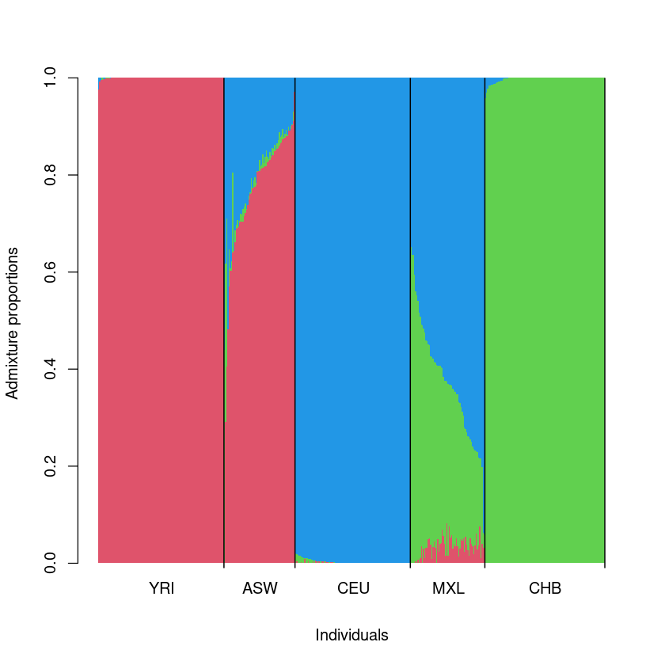

- Why do you think it looks cleaner than the previous admixture plot we visualized with the same individuals?
- How many populations would you now say are admixed? Which populations seem to be the admixture sources? Does that make sense given what you know of these populations?

## Assessing model fit

We will now use evalAdmix to assess if the ancestries inferred in our admixture results are a good approximation to the correct ancestries.

Again, due to time and computational limitations, we have already ran the command and just provide here the command used:

### How to read the correlation of residuals

The admixture model predicts, for each individual and site, an expected genotype - its own mixture of the estimated ancestral frequencies. The **residual** is the difference between what we observed and that expectation. If the model is right, the residuals are noise: sequencing error and the randomness of which alleles an individual happened to inherit. Noise is independent between individuals, so the correlation between the residuals of any two individuals should be about 0.

If it is not, the two individuals deviate from the model *in the same direction*, and they do so because they share something the model does not know about. In the heatmap:

- a **block of positive correlation** covering a whole population means that population has ancestry that the K assumed ancestral populations cannot express, and it is being forced into a mixture of the ones we do have. Raising K is the usual remedy.
- a **single bright pair** off the diagonal usually means those two individuals are closely related.
- **negative correlation** between two groups is the mirror image of a positive block elsewhere - if some individuals are pulled one way, others must be pulled the other way for the frequencies to add up.

```
source ~/advBinf/admixtureHuman/env.sh   # paths + cd to the working folder

K=3
besti=3
inbgl=~/advBinf/admixtureHuman/data/admixinput/1000G5pops.inputgl.beagle.gz
inadmix=~/advBinf/admixtureHuman/data/admixoutput/1000G5popsAdmixK${K}seed${besti}
out=~/advBinf/admixtureHuman/data/evaladmixoutput/1000G5pops.K${K}seed${besti}.corres

echo "$EVALADMIX -beagle $inbgl -fname ${inadmix}.fopt.gz -qname ${inadmix}.qopt -o $out -P 20"
```

```
evalAdmix -beagle /home/albrecht/advBinf/admixtureHuman/data/admixinput/1000G5pops.inputgl.beagle.gz -fname /home/albrecht/advBinf/admixtureHuman/data/admixoutput/1000G5popsAdmixK3seed3.fopt.gz -qname /home/albrecht/advBinf/admixtureHuman/data/admixoutput/1000G5popsAdmixK3seed3.qopt -o /home/albrech…
```

We will now visualize the correlation of residuals estimated by evalAdmix, and use it to assess whether the estimated admixture proportions results are a good fit to the data.

```
# Import some funcitons to help in visualization
source("https://raw.githubusercontent.com/GenisGE/evalAdmix/master/visFuns.R")

# Read in info to plot
pop<-read.table("~/advBinf/admixtureHuman/data/admixinput/1000G5pops.pop.info",as.is=T)
q<-read.table("~/advBinf/admixtureHuman/data/admixoutput/1000G5popsAdmixK3seed3.qopt")
r <- as.matrix(read.table("~/advBinf/admixtureHuman/data/evaladmixoutput/1000G5pops.K3seed3.corres"))

# Sort individuals by population and within populations by admixture proportion
ord<-orderInds(pop = pop[,1], q=q)

# Make plot
plotCorRes(r, pop=pop[,1], ord=ord, max_z = 0.2)
```

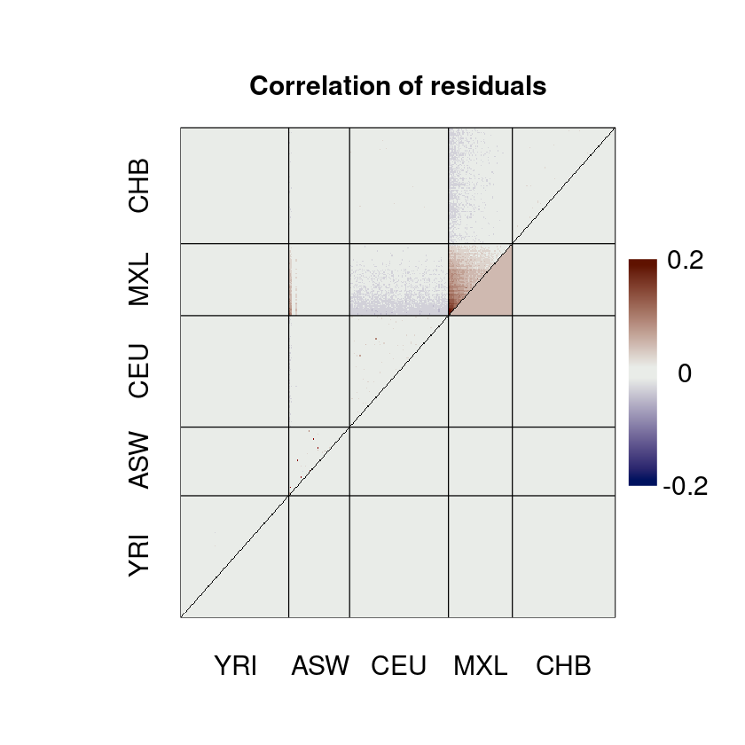

- Is there any population for which the estimated admixture proportions do not seem to have a good fit?
- Looking at the admixture proportions plot, can you think of a reason why that population might not be correctly modelled?

### Quiz

```
from jupyterquiz import display_quiz
display_quiz('admix_quiz4.json')
```

## Trying other values of K

We will now do again the analyses but using 4 instead of 3 ancestral populations. We start by doing 20 independent runs of NGSadmix, with the same settings except that this time we use K = 4.

We then collect the likelihoods form the log files and look at them to assess if the optimization has converged to the global maximum likelihood.

Again, the analyses has already been run and we just provide the code to print the commands:

```
source ~/advBinf/admixtureHuman/env.sh   # paths + cd to the working folder

inputpath=~/advBinf/admixtureHuman/data/admixinput/1000G5pops.inputgl.beagle.gz
outpath=~/advBinf/admixtureHuman/data/admixoutput
K=4

for i in `seq 1 20`
do
    echo "$NGSadmix -likes $inputpath -K $K -P 10 -minMaf 0.05 -seed $i -o ${outpath}/1000G5popsAdmixK${K}seed${i}"
done

outadmix=~/advBinf/admixtureHuman/data/admixoutput/1000G5popsAdmix
rm -f allK${K}.likes
for i in `seq 1 20`
do
    cat ${outadmix}K${K}seed$i.log | grep "best like" | awk -F"[ =]" '{print $3}' >> allK${K}.likes
done
```

```
NGSadmix -likes /home/albrecht/advBinf/admixtureHuman/data/admixinput/1000G5pops.inputgl.beagle.gz -K 4 -P 10 -minMaf 0.05 -seed 1 -o /home/albrecht/advBinf/admixtureHuman/data/admixoutput/1000G5popsAdmixK4seed1
NGSadmix -likes /home/albrecht/advBinf/admixtureHuman/data/admixinput/1000G5pops.inputgl.beagle.gz -K 4 -P 10 -minMaf 0.05 -seed 2 -o /home/albrecht/advBinf/admixtureHuman/data/admixoutput/1000G5popsAdmixK4seed2
NGSadmix -likes /home/albrecht/advBinf/admixtureHuman/data/admixinput/1000G5pops.inputgl.beagle.gz -K 4 -P 10 -minMaf 0.05 -seed 3 -o /home/albrecht/advBinf/admixtureHuman/data/admixoutput/1000G5popsAdmixK4seed3
NGSadmix -likes /home/albrecht/advBinf/admixtureHuman/data/admixinput/1000G5pops.inputgl.beagle.gz -K 4 -P 10 -minMaf 0.05 -seed 4 -o /home/albrecht/advBinf/admixtureHuman/data/admixoutput/1000G5popsAdmixK4seed4
NGSadmix -likes /home/albrecht/advBinf/admixtureHuman/data/admixinput/1000G5pops.inputgl.beagle.gz -K 4 -P 10 -minMaf 0.05 -seed 5 -o /home/albrecht/advBinf/admixtureHuman/data/admixoutput/1000G5popsAdmixK4seed5
NGSadmix -likes /home/albrecht/advBinf/admixtureHuman/data/admixinput/1000G5pops.inputgl.beagle.gz -K 4 -P 10 -minMaf 0.05 -seed 6 -o /home/albrecht/advBinf/admixtureHuman/data/admixoutput/1000G5popsAdmixK4seed6
NGSadmix -likes /home/albrecht/advBinf/admixtureHuman/data/admixinput/1000G5pops.inputgl.beagle.gz -K 4 -P 10 -minMaf 0.05 -seed 7 -o /home/albrecht/advBinf/admixtureHuman/data/admixoutput/1000G5popsAdmixK4seed7
NGSadmix -likes /home/albrecht/advBinf/admixtureHuman/data/admixinput/1000G5pops.inputgl.beagle.gz -K 4 -P 10 -minMaf 0.05 -seed 8 -o /home/albrecht/advBinf/admixtureHuman/data/admixoutput/1000G5popsAdmixK4seed8
NGSadmix -likes /home/albrecht/advBinf/admixtureHuman/data/admixinput/1000G5pops.inputgl.beagle.gz -K 4 -P 10 -minMaf 0.05 -seed 9 -o /home/albrecht/advBinf/admixtureHuman/data/admixoutput/1000G5popsAdmixK4seed9
NGSadmix -likes /home/albrecht/advBinf/admixtureHuman/data/admixinput/1000G5pops.inputgl.beagle.gz -K 4 -P 10 -minMaf 0.05 -seed 10 -o /home/albrecht/advBinf/admixtureHuman/data/admixoutput/1000G5popsAdmixK4seed10
NGSadmix -likes /home/albrecht/advBinf/admixtureHuman/data/admixinput/1000G5pops.inputgl.beagle.gz -K 4 -P 10 -minMaf 0.05 -seed 11 -o /home/albrecht/advBinf/admixtureHuman/data/admixoutput/1000G5popsAdmixK4seed11
NGSadmix -likes /home/albrecht/advBinf/admixtureHuman/data/admixinput/1000G5pops.inputgl.beagle.gz -K 4 -P 10 -minMaf 0.05 -seed 12 -o /home/albrecht/advBinf/admixtureHuman/data/admixoutput/1000G5popsAdmixK4seed12
NGSadmix -likes /home/albrecht/advBinf/admixtureHuman/data/admixinput/1000G5pops.inputgl.beagle.gz -K 4 -P 10 -minMaf 0.05 -seed 13 -o /home/albrecht/advBinf/admixtureHuman/data/admixoutput/1000G5popsAdmixK4seed13
NGSadmix -likes /home/albrecht/advBinf/admixtureHuman/data/admixinput/1000G5pops.inputgl.beagle.gz -K 4 -P 10 -minMaf 0.05 -seed 14 -o /home/albrecht/advBinf/admixtureHuman/data/admixoutput/1000G5popsAdmixK4seed14
NGSadmix -likes /home/albrecht/advBinf/admixtureHuman/data/admixinput/1000G5pops.inputgl.beagle.gz -K 4 -P 10 -minMaf 0.05 -seed 15 -o /home/albrecht/advBinf/admixtureHuman/data/admixoutput/1000G5popsAdmixK4seed15
NGSadmix -likes /home/albrecht/advBinf/admixtureHuman/data/admixinput/1000G5pops.inputgl.beagle.gz -K 4 -P 10 -minMaf 0.05 -seed 16 -o /home/albrecht/advBinf/admixtureHuman/data/admixoutput/1000G5popsAdmixK4seed16
NGSadmix -likes /home/albrecht/advBinf/admixtureHuman/data/admixinput/1000G5pops.inputgl.beagle.gz -K 4 -P 10 -minMaf 0.05 -seed 17 -o /home/albrecht/advBinf/admixtureHuman/data/admixoutput/1000G5popsAdmixK4seed17
NGSadmix -likes /home/albrecht/advBinf/admixtureHuman/data/admixinput/1000G5pops.inputgl.beagle.gz -K 4 -P 10 -minMaf 0.05 -seed 18 -o /home/albrecht/advBinf/admixtureHuman/data/admixoutput/1000G5popsAdmixK4seed18
NGSadmix -likes /home/albrecht/advBinf/admixtureHuman/data/admixinput/1000G5pops.inputgl.beagle.gz -K 4 -P 10 -minMaf 0.05 -seed 19 -o /home/albrecht/advBinf/admixtureHuman/data/admixoutput/1000G5popsAdmixK4seed19
NGSadmix -likes /home/albrecht/advBinf/admixtureHuman/data/admixinput/1000G5pops.inputgl.beagle.gz -K 4 -P 10 -minMaf 0.05 -seed 20 -o /home/albrecht/advBinf/admixtureHuman/data/admixoutput/1000G5popsAdmixK4seed20
```

- Can you spot the how the code is different from the code for K=3?

Now try to looks at the log likelihoods for the 20 runs sorted from best (top) to worst (bottom):

```
source ~/advBinf/admixtureHuman/env.sh   # paths + cd to the working folder

cat -n allK${K}.likes | sort -rhk2
```

```
     9	-34654597.394711
    11	-34654597.515125
    18	-34654597.670429
     8	-34654597.952226
    14	-34654598.071523
    15	-34654598.103667
    12	-34654598.140408
     6	-34654598.168480
     7	-34654598.240863
     2	-34654598.267312
     5	-34654598.331777
     1	-34654598.381587
     4	-34654598.408025
    13	-34654598.584358
    17	-34654598.753065
    19	-34654599.566582
     3	-34654599.613498
    10	-34654600.335350
    16	-34654601.539070
    20	-34654603.772069
```

- Does it look we reached convergence for K=4?

We will now run evalAdmix to assess the model fit of the best admixture run (again, it has been pre run and we just print the command):

```
source ~/advBinf/admixtureHuman/env.sh   # paths + cd to the working folder

K=4
besti=9
inbgl=~/advBinf/admixtureHuman/data/admixinput/1000G5pops.inputgl.beagle.gz
inadmix=~/advBinf/admixtureHuman/data/admixoutput/1000G5popsAdmixK${K}seed${besti}
out=~/advBinf/admixtureHuman/data/evaladmixoutput/1000G5pops.K${K}seed${besti}.corres

echo "$EVALADMIX -beagle $inbgl -fname ${inadmix}.fopt.gz -qname ${inadmix}.qopt -o $out -P 20"
```

```
evalAdmix -beagle /home/albrecht/advBinf/admixtureHuman/data/admixinput/1000G5pops.inputgl.beagle.gz -fname /home/albrecht/advBinf/admixtureHuman/data/admixoutput/1000G5popsAdmixK4seed9.fopt.gz -qname /home/albrecht/advBinf/admixtureHuman/data/admixoutput/1000G5popsAdmixK4seed9.qopt -o /home/albrech…
```

We will now visualize the estimated admixture proporitons and the correlation of residuals to assess their fit:

```
source("https://raw.githubusercontent.com/GenisGE/evalAdmix/master/visFuns.R") # import some funcitons to help in visualization
pop<-read.table("~/advBinf/admixtureHuman/data/admixinput/1000G5pops.pop.info",as.is=T)
q<-read.table("~/advBinf/admixtureHuman/data/admixoutput/1000G5popsAdmixK4seed9.qopt")


ord<-orderInds(pop = pop[,1], q=q) # sort indiivduals by population and within populaoitn by admixture proportion

# plot admixture proportions
barplot(t(q)[,ord],col=c(5,4,2,3),space=0,border=NA,xlab="Individuals",ylab="Admixture proportions")
text(sort(tapply(1:nrow(pop),pop[ord,1],mean)),-0.05,unique(pop[ord,1]),xpd=T) # add population labels
abline(v=cumsum(sapply(unique(pop[ord,1]),function(x){sum(pop[ord,1]==x)})),col=1,lwd=1.2)

r <- as.matrix(read.table("~/advBinf/admixtureHuman/data/evaladmixoutput/1000G5pops.K4seed9.corres"))
plotCorRes(r, pop=pop[,1], ord=ord, max_z = 0.2)
```

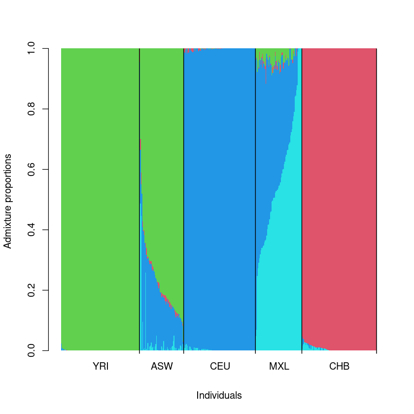

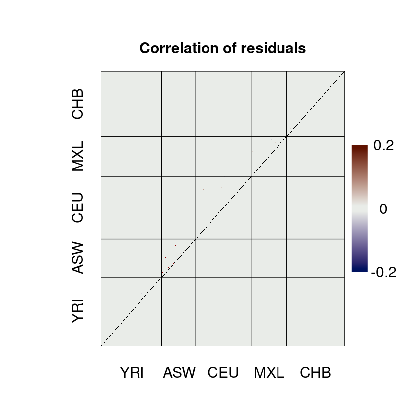

- What population does the new cluster that we have added correspond to?
- Based on the correlation of residuals, would you say adding that cluster has given a significant improvement to the model fit?

# B. Use of fastNGSadmix to infer admixture proportions for 3 samples

Let's try to use fastNGSadmix. Specifically, let's see if we can use it to infer the ancestry of 3 samples: sample1, sample2 and sample3.

## Setup paths

To this first setup some paths by typing this in the terminal:

### How fastNGSadmix differs

NGSadmix estimated the ancestral allele frequencies and the admixture proportions at the same time, which is only possible because we had hundreds of samples. With a single sample that is hopeless - there is no way to tell an unusual individual from an unusual population.

fastNGSadmix therefore takes the ancestral allele frequencies as *given*, from a reference panel of populations that someone has already characterised, and estimates only the admixture proportions of the one sample. That makes it fast enough to run on a laptop, and it is how ancestry is inferred for single ancient or forensic samples. The price is that the answer can only ever be phrased in terms of the populations that are in the panel, which is something we will test directly below.

```
source ~/advBinf/admixtureHuman/env.sh   # paths + cd to the working folder

# Set path for all input files you will use in this exercise
inputpath=~/advBinf/admixtureHuman/data/fastNGSadmixinput/
```

## Explore the files with the reference panel

As reference panel we will use data from these 7 populations:

| Population code/name | Description |
| --- | --- |
| French | French individuals |
| Han | Chinese individuals |
| Chukchi | Siberian individuals |
| Karitiana | Native American individuals |
| Papuan | Individuals from Papua New Guinea, Melanesia |
| Sindhi | Individuals from India |
| YRI | Yoruba individuals from Nigeria |

The files with genotype likelihood (GL) data from sample1, sample2 and sample3 are in beagle format — so exactly the same format as the input files you used for NGSadmix. So let's not spend time on looking at those. But before we start analysing the data then have a quick look at the files with the reference panel (nInd.txt and refPanel.txt) so you know how they look (in case you at some point want to create your own reference panel - which there are scripts for that comes with fastNGSadmix). You can do this by running the following commands:

```
source ~/advBinf/admixtureHuman/env.sh   # paths + cd to the working folder

# Show the full content of the file nInd.txt
# (a file that has info how many samples from each population the panel consists of)
echo "Content of nInd.txt:"
cat ${inputpath}/nInd.txt | column -t

# Show the top 2 lines of the file refPanel.txt
# (a file that has info about allele frequencies for the 7 populations)
echo ""
echo "First 2 lines of refPanel.txt"
head -n2 ${inputpath}/refPanel.txt | column -t
```

```
Content of nInd.txt:
French  Han  Chukchi  Karitiana  Papuan  Sindhi  Yoruba
25      33   23       12         14      18      70

First 2 lines of refPanel.txt
id        chr  pos     name       A0_freq  A1  French             Han                 Chukchi            Karitiana           Papuan              Sindhi             Yoruba
1_752566  1    752566  rs3094315  G        A   0.166666666666667  0.0606060606060606  0.369565217391304  0.0833333333333334  0.0714285714285714  0.305555555555556  0.671428571428571
```

- How many samples from each population does the reference population consist of?
- What are the allele frequencies of the first SNP for each of the populations?

## Analyse the samples with fastNGSadmix

Let's try to run fastNGSadmix on the 3 samples one at a time with the following commands:

```
source ~/advBinf/admixtureHuman/env.sh   # paths + cd to the working folder

# Analyse sample1
$fastNGSadmix -likes ${inputpath}/sample1.beagle -fname ${inputpath}/refPanel.txt -Nname ${inputpath}/nInd.txt -outfiles sample1 -whichPops all -conv 10 -seed 1

# Analyse sample2
$fastNGSadmix -likes ${inputpath}/sample2.beagle.gz -fname ${inputpath}/refPanel.txt -Nname ${inputpath}/nInd.txt -outfiles sample2 -whichPops all -conv 10 -seed 1

# Analyse sample3
$fastNGSadmix -likes ${inputpath}/sample3.beagle.gz -fname ${inputpath}/refPanel.txt -Nname ${inputpath}/nInd.txt -outfiles sample3 -whichPops all -conv 10 -seed 1
```

```
	-> Dumping file: sample1.log
Input: -likes /home/albrecht/advBinf/admixtureHuman/data/fastNGSadmixinput//sample1.beagle -plink (null) -Nname /home/albrecht/advBinf/admixtureHuman/data/fastNGSadmixinput//nInd.txt -fname /home/albrecht/advBinf/admixtureHuman/data/fastNGSadmixinput//refPanel.txt -out sample1 -whichPops all
Setup: -seed 1 -method 1
Ploidy of 2 has been chosen

The accelerated EM has been chosen
The adjusted method has been chosen
Convergence: -maxIter 2000 -tol 0.00000010
The following number of bootstraps have been chosen: 0
Input has this many sites without missing data 49643
Ref has this many sites 442769
This many sites in ref are either not-valid-number or below maf in any of the chosen pops 0
Overlap: of 49643 sites between input and ref
Chosen pop French
Chosen pop Han
Chosen pop Chukchi
Chosen pop Karitiana
Chosen pop Papuan
Chosen pop Sindhi
Chosen pop Yoruba


nPop=7

Opening nInd file: /home/albrecht/advBinf/admixtureHuman/data/fastNGSadmixinput//nInd.txt with nPop=7
N = 25.000000
N = 33.000000
N = 23.000000
N = 12.000000
N = 14.000000
N = 18.000000
N = 70.000000

iter[start] like is=-45599.395219
iter[10] like=-42588.237624 alpha=1.206794 Q=0.683390, Q=0.217322, Q=0.006654, Q=0.003508, Q=0.003601, Q=0.005810, Q=0.079714,
iter[20] like=-42566.450900 alpha=2.534922 Q=0.689830, Q=0.229277, Q=0.000138, Q=0.000201, Q=0.000129, Q=0.000026, Q=0.080399,
iter[30] like=-42566.129804 alpha=1.884067 Q=0.689904, Q=0.229520, Q=0.000039, Q=0.000075, Q=0.000042, Q=0.000010, Q=0.080410,
like after -42566.012275
CONVERGENCE!
This many iterations 40 for run 0
```

[output cut: 250 more lines]

```
Q 0.000010 Q 0.000010 Q 0.000010 Q 0.999940 Q 0.000010 Q 0.000010 Q 0.000010  after 5!
best like -66.756418 after 6!
Q 0.000010 Q 0.000020 Q 0.000010 Q 0.999930 Q 0.000010 Q 0.000010 Q 0.000010  after 6!
best like -66.756364 after 7!
Q 0.000010 Q 0.000010 Q 0.000010 Q 0.999940 Q 0.000010 Q 0.000010 Q 0.000010  after 7!
best like -66.751012 after 8!
Q 0.000010 Q 0.000010 Q 0.000010 Q 0.999940 Q 0.000010 Q 0.000010 Q 0.000010  after 8!
best like -66.756966 after 9!
Q 0.000010 Q 0.000010 Q 0.000010 Q 0.999940 Q 0.000010 Q 0.000010 Q 0.000010  after 9!

Estimated  Q = 0.000010 0.000010 0.000010 0.999940 0.000010 0.000010 0.000010 best like -66.751012 after 8 runs!
	-> Dumping file: sample3.qopt
FIRST row of .qopt file is BEST estimated Q, rest are nBoot bootstrapping Qs
	[ALL done] cpu-time used =  0.01 sec
	[ALL done] walltime used =  0.00 sec
```

As you can see the way to run it is similar to NGSadmix. The options -likes and -outfiles are the same (-outfiles is the equivalent of -o in NGSadmix). But now we also have the -fname and -Nname, which allows you to specify files with your reference panel. Also notice you can ask to run multiple runs with different starting points using the option -conv which makes it easier to ensure convergence. And then there is actually one more parameter that has to be set, namely -whichPops which allows you to specify that you only want to use a subset of the populations in the reference panel, or that you want to analyze all populations. So e.g. try to re-analyse sample1 using only 6 of the 7 populations in your reference panel (excluding the French) by running the same code as before except with -whichPops changed:

```
source ~/advBinf/admixtureHuman/env.sh   # paths + cd to the working folder

# Re-analyse sample1 with a smaller reference panel
$fastNGSadmix -likes ${inputpath}/sample1.beagle -fname ${inputpath}/refPanel.txt -Nname ${inputpath}/nInd.txt -outfiles sample1V2 -whichPops Han,Yoruba,Sindhi,Papuan,Chukchi,Karitiana -conv 10 -seed 1
```

```
	-> Dumping file: sample1V2.log
Input: -likes /home/albrecht/advBinf/admixtureHuman/data/fastNGSadmixinput//sample1.beagle -plink (null) -Nname /home/albrecht/advBinf/admixtureHuman/data/fastNGSadmixinput//nInd.txt -fname /home/albrecht/advBinf/admixtureHuman/data/fastNGSadmixinput//refPanel.txt -out sample1V2 -whichPops Han,Yorub…
Setup: -seed 1 -method 1
Ploidy of 2 has been chosen

The accelerated EM has been chosen
The adjusted method has been chosen
Convergence: -maxIter 2000 -tol 0.00000010
The following number of bootstraps have been chosen: 0
Input has this many sites without missing data 49643
Ref has this many sites 442769
This many sites in ref are either not-valid-number or below maf in any of the chosen pops 0
Overlap: of 49643 sites between input and ref
Chosen pop Han
Chosen pop Chukchi
Chosen pop Karitiana
Chosen pop Papuan
Chosen pop Sindhi
Chosen pop Yoruba


nPop=6

Opening nInd file: /home/albrecht/advBinf/admixtureHuman/data/fastNGSadmixinput//nInd.txt with nPop=6
N = 33.000000
N = 23.000000
N = 12.000000
N = 14.000000
N = 18.000000
N = 70.000000

iter[start] like is=-46402.522441
iter[10] like=-43844.174959 alpha=11.977057 Q=0.200189, Q=0.019488, Q=0.014318, Q=0.009390, Q=0.631908, Q=0.124707,
iter[20] like=-43815.199299 alpha=59.015880 Q=0.223665, Q=0.005684, Q=0.005879, Q=0.001145, Q=0.638470, Q=0.125158,
iter[30] like=-43810.965481 alpha=10.444128 Q=0.227087, Q=0.003098, Q=0.004414, Q=0.000389, Q=0.639826, Q=0.125186,
iter[40] like=-43808.333811 alpha=17.591278 Q=0.229252, Q=0.001431, Q=0.003346, Q=0.000086, Q=0.640701, Q=0.125184,
iter[50] like=-43807.536199 alpha=13.651140 Q=0.229926, Q=0.000928, Q=0.002946, Q=0.000037, Q=0.640985, Q=0.125178,
iter[60] like=-43806.366883 alpha=3.755357 Q=0.230914, Q=0.000258, Q=0.002233, Q=0.000010, Q=0.641422, Q=0.125163,
iter[70] like=-43805.899067 alpha=1.872164 Q=0.231297, Q=0.000078, Q=0.001843, Q=0.000010, Q=0.641616, Q=0.125155,
iter[80] like=-43805.628161 alpha=6.010240 Q=0.231510, Q=0.000023, Q=0.001568, Q=0.000010, Q=0.641738, Q=0.125151,
```

[output cut: 67 more lines]

```
Q 0.232195 Q 0.000010 Q 0.000471 Q 0.000010 Q 0.642178 Q 0.125136  after 5!
best like -43804.714722 after 6!
Q 0.232200 Q 0.000010 Q 0.000463 Q 0.000010 Q 0.642181 Q 0.125136  after 6!
best like -43804.676024 after 7!
Q 0.232230 Q 0.000010 Q 0.000414 Q 0.000010 Q 0.642201 Q 0.125135  after 7!
best like -43804.719086 after 8!
Q 0.232198 Q 0.000010 Q 0.000467 Q 0.000010 Q 0.642180 Q 0.125136  after 8!
best like -43804.748626 after 9!
Q 0.232175 Q 0.000010 Q 0.000503 Q 0.000010 Q 0.642165 Q 0.125136  after 9!

Estimated  Q = 0.232230 0.000010 0.000414 0.000010 0.642201 0.125135 best like -43804.676024 after 7 runs!
	-> Dumping file: sample1V2.qopt
FIRST row of .qopt file is BEST estimated Q, rest are nBoot bootstrapping Qs
	[ALL done] cpu-time used =  44.35 sec
	[ALL done] walltime used =  44.00 sec
```

## Take a look at the output files

The output is very similar to that of NGSadmix. There is no fopt file, but there is a log file and and qopt file.

Try to look in the log files for the four analyses using the command cat, so e.g. for sample1 type:

```
source ~/advBinf/admixtureHuman/env.sh   # paths + cd to the working folder

# Show content of sample1.log
cat sample1.log
```

```
Input: -likes /home/albrecht/advBinf/admixtureHuman/data/fastNGSadmixinput//sample1.beagle -plink (null) -Nname /home/albrecht/advBinf/admixtureHuman/data/fastNGSadmixinput//nInd.txt -fname /home/albrecht/advBinf/admixtureHuman/data/fastNGSadmixinput//refPanel.txt -out sample1 -whichPops all
Setup: -seed 1 -method 1
Ploidy of 2 has been chosen

The accelerated EM has been chosen
The adjusted method has been chosen
Convergence: -maxIter 2000 -tol 0.00000010
The following number of bootstraps have been chosen: 0
Input has this many sites without missing data 49643
Ref has this many sites 442769
This many sites in ref are either not-valid-number or below maf in any of the chosen pops 0
Overlap: of 49643 sites between input and ref

nPop=7

Opening nInd file: /home/albrecht/advBinf/admixtureHuman/data/fastNGSadmixinput//refPanel.txt with nPop=7
Chosen pop French
N = 25.000000
Chosen pop Han
N = 33.000000
Chosen pop Chukchi
N = 23.000000
Chosen pop Karitiana
N = 12.000000
Chosen pop Papuan
N = 14.000000
Chosen pop Sindhi
N = 18.000000
Chosen pop Yoruba
N = 70.000000

This many iterations 40 for run 0

This many iterations 35 for run 1

This many iterations 53 for run 2

This many iterations 40 for run 3

This many iterations 53 for run 4
```

[output cut: 22 more lines]

```
Q 0.689929 Q 0.229618 Q 0.000010 Q 0.000010 Q 0.000010 Q 0.000010 Q 0.080413  after 5!
best like -42566.012995 after 6!
Q 0.689928 Q 0.229618 Q 0.000010 Q 0.000010 Q 0.000010 Q 0.000010 Q 0.080413  after 6!
best like -42566.012110 after 7!
Q 0.689929 Q 0.229618 Q 0.000010 Q 0.000010 Q 0.000010 Q 0.000010 Q 0.080413  after 7!
best like -42566.012820 after 8!
Q 0.689928 Q 0.229618 Q 0.000010 Q 0.000010 Q 0.000010 Q 0.000010 Q 0.080414  after 8!
best like -42566.012710 after 9!
Q 0.689929 Q 0.229619 Q 0.000010 Q 0.000010 Q 0.000010 Q 0.000010 Q 0.080413  after 9!

Estimated  Q = 0.689929 0.229618 0.000010 0.000010 0.000010 0.000010 0.080413
best like -42566.011425 after 5 runs!
FIRST row of .qopt file is BEST estimated Q, rest are nBoot bootstrapping Qs
	[ALL done] cpu-time used =  9.46 sec
	[ALL done] walltime used =  9.00 sec
```

- How many loci are the 4 different analyses based on (this is in the log files and is called Overlap)?

Next try to have a look at the qopt file for sample 1 (which like for NGSadmix contains the estimated admixture proportion for the sample):

```
source ~/advBinf/admixtureHuman/env.sh   # paths + cd to the working folder

# Show content of sample1.qopt
cat sample1.qopt | column -t
```

```
French  Han     Chukchi  Karitiana  Papuan  Sindhi  Yoruba
0.6899  0.2296  0.0000   0.0000     0.0000  0.0000  0.0804
```

- Does the sample look admixed?

## Plot the analysis results

Instead of reading all the qopt files one at a time, let us plot the results of all 4 analyses in R:

```
# Plot results for first analysis of sample1
admix<-read.table("~/advBinf/admixtureHuman/sample1.qopt",as.is=T,h=T)
barplot(as.matrix(admix),ylab="Admixture proportion",col="red",ylim=c(0,1),main="Sample1")

# Plot results for 2nd analysis of sample1 (the one where we excluded French from the reference panel)
admix<-read.table("~/advBinf/admixtureHuman/sample1V2.qopt",as.is=T,h=T)
barplot(as.matrix(admix),ylab="Admixture proportion",col="red",ylim=c(0,1),main="Sample1 (re-analysed)")

# Plot results for analysis of sample2
admix<-read.table("~/advBinf/admixtureHuman/sample2.qopt",as.is=T,h=T)
barplot(as.matrix(admix),ylab="Admixture proportion",col="red",ylim=c(0,1),main="Sample2")

# Plot results for analysis of sample3
admix<-read.table("~/advBinf/admixtureHuman/sample3.qopt",as.is=T,h=T)
barplot(as.matrix(admix),ylab="Admixture proportion",col="red",ylim=c(0,1),main="Sample3")
```

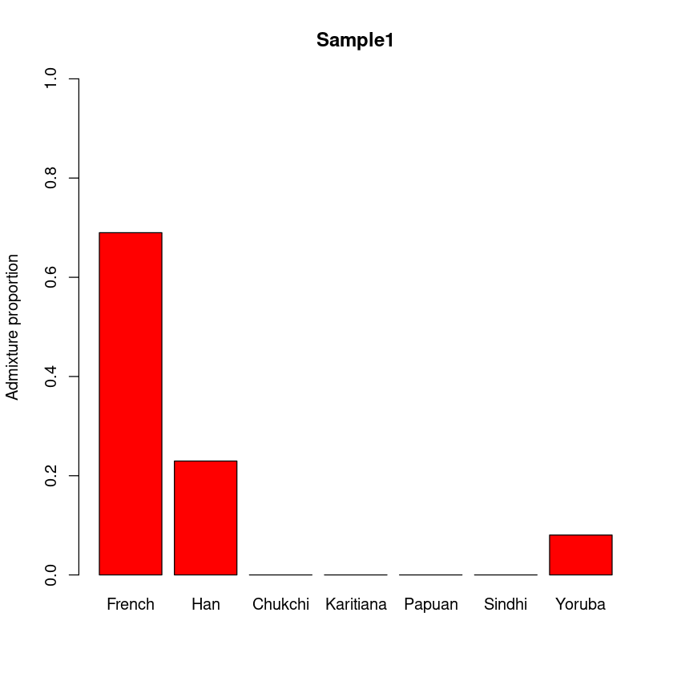

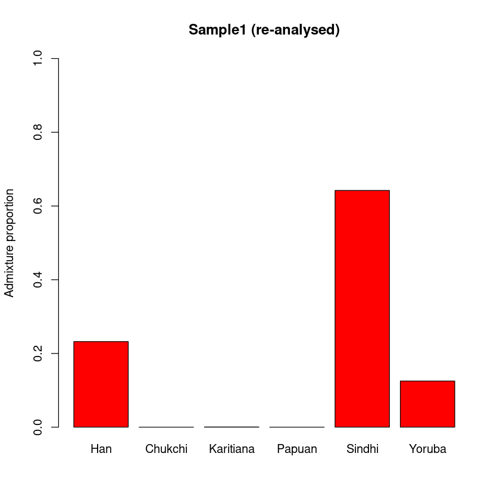

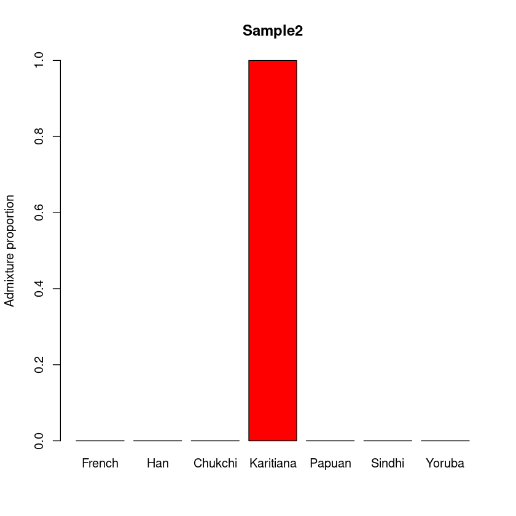

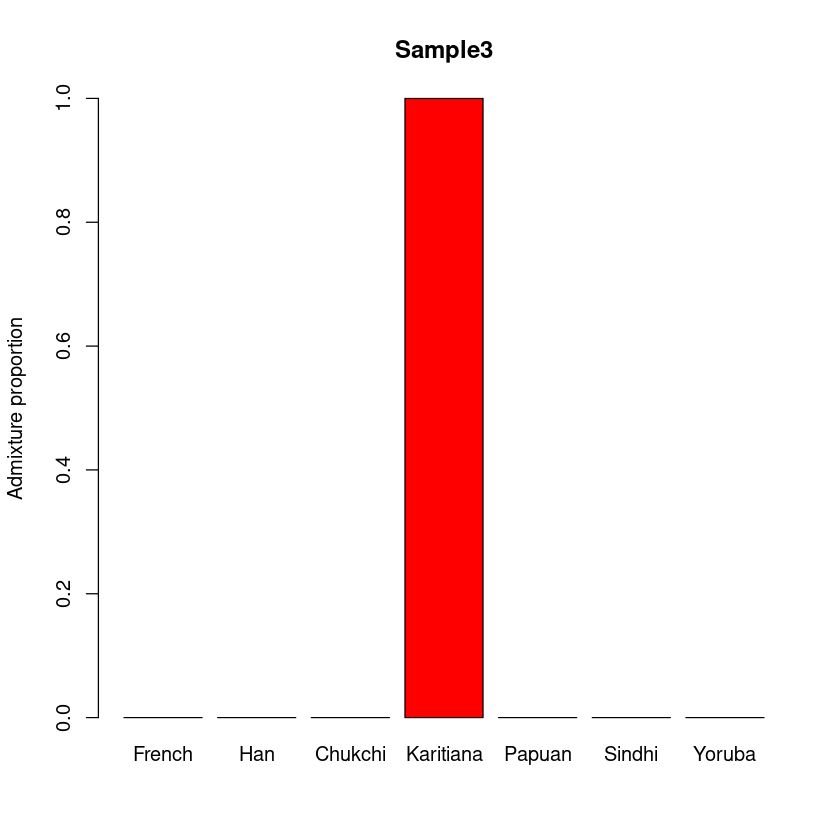

Based on the results:

- what ancestry do you think the three samples have (ignore the second analysis of sample1 for now)?

Now look at the results of the second analysis of sample1 (for which a different reference panel was used).

- Why do you think the result depends on the reference panel and what are the consequences?

Finally

- Do you trust the results for sample2 and sample3 given the number of loci it is based on?

In order to investigate this we can let fastNGSadmix run with bootstraps, where we randomly sample (with replacement), the sites the analysis is based on. This tells us something about how susceptible our estimates are to change. Try to run fastNGSadmix with 100 bootstraps for sample2 and sample3:

### How sure are we?

A point estimate on its own says nothing about how much data it rests on. sample2 and sample3 differ a lot in how many sites they share with the reference panel, and an estimate based on a few hundred sites can move a long way if you happen to look at a different few hundred sites.

The `-boot` option measures exactly that: it resamples the sites with replacement 100 times and re-estimates the proportions from each resampled set. The spread of those 100 estimates is a confidence interval for the estimate. Note what it does *not* cover - resampling sites cannot tell you that a source population is missing from your panel, so narrow intervals are not the same as a correct answer.

```
source ~/advBinf/admixtureHuman/env.sh   # paths + cd to the working folder

$fastNGSadmix -likes ${inputpath}/sample2.beagle.gz -fname ${inputpath}/refPanel.txt -Nname ${inputpath}/nInd.txt -outfiles sample2boot -whichPops all -boot 100

$fastNGSadmix -likes ${inputpath}/sample3.beagle.gz -fname ${inputpath}/refPanel.txt -Nname ${inputpath}/nInd.txt -outfiles sample3boot -whichPops all -boot 100
```

```
	-> Dumping file: sample2boot.log
Input: -likes /home/albrecht/advBinf/admixtureHuman/data/fastNGSadmixinput//sample2.beagle.gz -plink (null) -Nname /home/albrecht/advBinf/admixtureHuman/data/fastNGSadmixinput//nInd.txt -fname /home/albrecht/advBinf/admixtureHuman/data/fastNGSadmixinput//refPanel.txt -out sample2boot -whichPops all
Setup: -seed 1789383174 -method 1
Ploidy of 2 has been chosen

The accelerated EM has been chosen
The adjusted method has been chosen
Convergence: -maxIter 2000 -tol 0.00000010
The following number of bootstraps have been chosen: 100
Input has this many sites without missing data 20903
Ref has this many sites 442769
This many sites in ref are either not-valid-number or below maf in any of the chosen pops 0
Overlap: of 20903 sites between input and ref
Chosen pop French
Chosen pop Han
Chosen pop Chukchi
Chosen pop Karitiana
Chosen pop Papuan
Chosen pop Sindhi
Chosen pop Yoruba


nPop=7

Opening nInd file: /home/albrecht/advBinf/admixtureHuman/data/fastNGSadmixinput//nInd.txt with nPop=7
N = 25.000000
N = 33.000000
N = 23.000000
N = 12.000000
N = 14.000000
N = 18.000000
N = 70.000000

iter[start] like is=-17931.974338
iter[10] like=-14965.533032 alpha=1.979718 Q=0.000872, Q=0.012253, Q=0.027182, Q=0.957539, Q=0.000094, Q=0.002050, Q=0.000010,
like after -14874.737505
CONVERGENCE!
This many iterations 19 for run 0

At this bootstrapping: 1 out of: 100
```

[output cut: 439 more lines]

```
CONVERGENCE!
At this bootstrapping: 98 out of: 100
CONVERGENCE!
At this bootstrapping: 99 out of: 100
CONVERGENCE!
At this bootstrapping: 100 out of: 100
CONVERGENCE!
best like -66.756493 after 0!
Q 0.000010 Q 0.000025 Q 0.000017 Q 0.999917 Q 0.000010 Q 0.000010 Q 0.000010  after 0!

Estimated  Q = 0.000010 0.000025 0.000017 0.999917 0.000010 0.000010 0.000010 best like -66.756493 after 0 runs!
	-> Dumping file: sample3boot.qopt
FIRST row of .qopt file is BEST estimated Q, rest are nBoot bootstrapping Qs
	[ALL done] cpu-time used =  0.05 sec
	[ALL done] walltime used =  0.00 sec
```

Notice that now the FIRST row of the .qopt files, are the estimated ancestry based on ALL sites, and that the subsequent rows, are the ones based on the bootstraps.

Now let us plot the results for sample3 in R:

```
# Plot estimates
admix<-read.table("~/advBinf/admixtureHuman/sample3boot.qopt",as.is=T,h=T)
b<-barplot(as.matrix(admix[1,]),main="sample3",ylab="Admixture proportion",col="red",ylim=c(0,1))

# Plot confidence intervals
## - first we take the 0.025 and 0.975 sample quantiles for constructing the confidence interval for out estimates
lower<-as.numeric(apply(admix,2,function(x) quantile(x[2:length(x)],probs=c(0.025))))
upper<-as.numeric(apply(admix,2,function(x) quantile(x[2:length(x)],probs=c(0.975))))

## - then we plot them
segments(b,lower,b,upper)
segments(b-0.2,lower,b+0.2,lower)
segments(b-0.2,upper,b+0.2,upper)
```

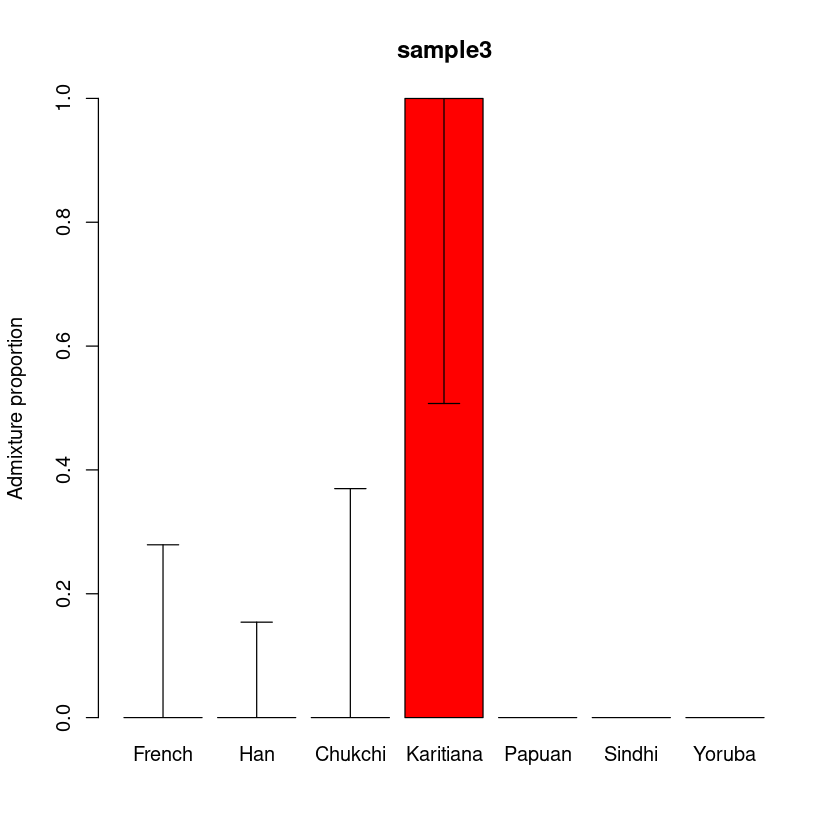

- Can you say with confidence what the ancestry of this sample is?

Let us also plot sample2 with 100 bootstraps:

```
# Plot estimates
admix<-read.table("~/advBinf/admixtureHuman/sample2boot.qopt",as.is=T,h=T)
b<-barplot(as.matrix(admix[1,]),main="sample2",ylab="Admixture proportion",col="red")

# Plot confidence intervals
## - first we take the 0.025 and 0.975 sample quantiles for constructing the confidence interval for out estimates
lower<-as.numeric(apply(admix,2,function(x) quantile(x[2:length(x)],probs=c(0.025))))
upper<-as.numeric(apply(admix,2,function(x) quantile(x[2:length(x)],probs=c(0.975))))

## - then we plot them
segments(b,lower,b,upper)
segments(b-0.2,lower,b+0.2,lower)
segments(b-0.2,upper,b+0.2,upper)
```

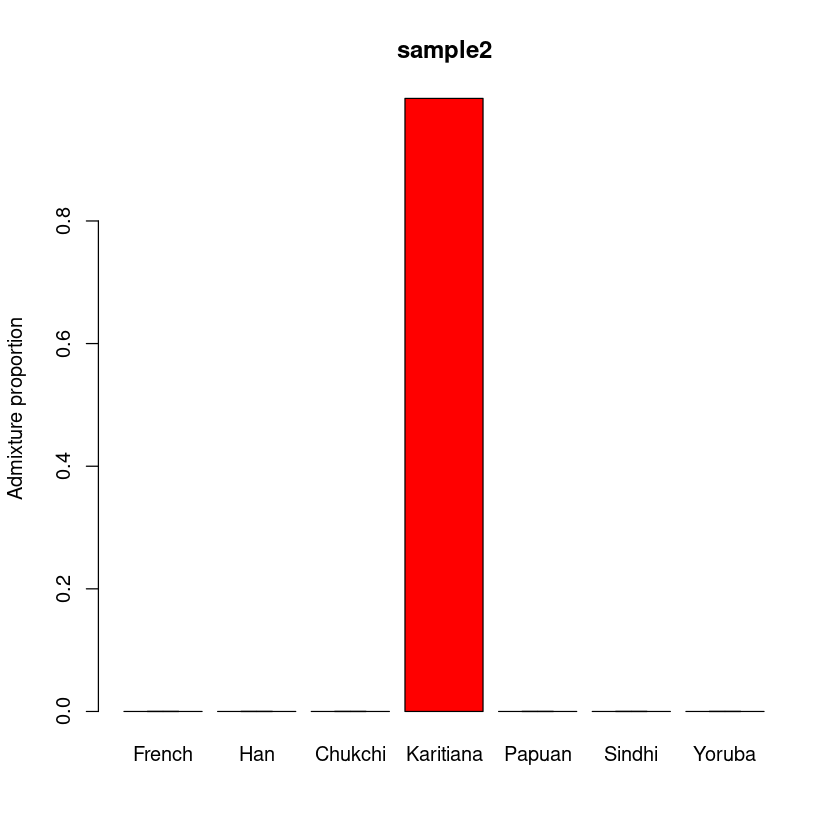

### Quiz

```
from jupyterquiz import display_quiz
display_quiz('admix_quiz5.json')
```

# C. The same questions with called genotypes: ADMIXTURE

NGSadmix works on genotype likelihoods because our data are low depth. When the data are good enough that genotypes can simply be called - a SNP chip, or high depth sequencing - the same admixture model is usually fitted with the program ADMIXTURE, and the convergence and model fit questions are exactly the same.

The bonus exercise walks through that on a dataset of blue wildebeest, where the consequences of a local optimum are considerably more dramatic than what you saw here:

[NGS admixture bonus notebook](https://github.com/popgenDK/courses/blob/main/advBinf/exercises/advBinf_admixture_bonus.ipynb)

Download it and upload it to the notebook server. If you get some odd error messages on the left hand side of the screen when you upload it then don't worry about it - pressing "Console" will usually make them go away.